# Lecture G - Statistical Models

Statistical Programming with R

## I use the following package in this lecture

```r
library(magrittr) #for pipes
library(MASS)     #for the cats and bacteria data
library(mice)     #for the boys data
```

### New functions

- `lm()` to run linear models

## Statistical models

## Statistical model

The mathematical formulation of relationship between variables can be written as

\[ \mbox{observed}=\mbox{predicted}+\mbox{error} \]

or (for the greek people) in notation as \[y=\mu+\varepsilon\]

where

- \(\mu\) (mean) is the part of \(Y\) that is explained by model
- \(\varepsilon\) (residual) is the part of \(Y\) that is not explained by model

## A simple example

Regression model:

- Model individual age from weight

\[ \text{age}_i=\alpha+\beta\cdot{\text{weight}}_i+\varepsilon_i \]

where

- \(\alpha+\beta{x}_i\) is the mean of `age`, \(y\), conditional on `weight`, \(x\).
- \(\varepsilon_i\) is random variation

## The linear model

The function `lm()` is a base function in `R` and allows you to pose a variety of linear models.

```r
args(lm)
```

```
## function (formula, data, subset, weights, na.action, method = "qr",
##     model = TRUE, x = FALSE, y = FALSE, qr = TRUE, singular.ok = TRUE,
##     contrasts = NULL, offset, ...)
## NULL
```

If we want to know what these arguments do we can ask R:

```r
?lm
```

This will open a help page on the `lm()` function.

## Continuous predictors

To obtain a linear model with a main effect for `wgt`, we formulate \(age\sim wgt\)

```r
fit <- boys %$%
  lm(age ~ wgt)
fit
```

```
##
## Call:
## lm(formula = age ~ wgt)
##
## Coefficients:
## (Intercept)          wgt
##     -0.1924       0.2517
```

## Continuous predictors: more detail

```r
fit %>% summary
```

```
##
## Call:
## lm(formula = age ~ wgt)
##
## Residuals:
##      Min       1Q   Median       3Q      Max
## -12.0907  -1.1686  -0.5342   1.4286   5.5143
##
## Coefficients:
##              Estimate Std. Error t value Pr(>|t|)
## (Intercept) -0.192377   0.136878  -1.405     0.16
## wgt          0.251673   0.003018  83.395   <2e-16 ***
## ---
## Signif. codes:  0 '***' 0.001 '**' 0.01 '*' 0.05 '.' 0.1 ' ' 1
##
## Residual standard error: 2.142 on 742 degrees of freedom
##   (4 observations deleted due to missingness)
## Multiple R-squared:  0.9036, Adjusted R-squared:  0.9035
## F-statistic:  6955 on 1 and 742 DF,  p-value: < 2.2e-16
```

## Continuous predictors

```r
require(mice)
fit <- boys %$%
  lm(age ~ wgt)
fit
```

```
##
## Call:
## lm(formula = age ~ wgt)
##
## Coefficients:
## (Intercept)          wgt
##     -0.1924       0.2517
```

## Continuous predictors: more detail

```r
fit %>% summary
```

```
##
## Call:
## lm(formula = age ~ wgt)
##
## Residuals:
##      Min       1Q   Median       3Q      Max
## -12.0907  -1.1686  -0.5342   1.4286   5.5143
##
## Coefficients:
##              Estimate Std. Error t value Pr(>|t|)
## (Intercept) -0.192377   0.136878  -1.405     0.16
## wgt          0.251673   0.003018  83.395   <2e-16 ***
## ---
## Signif. codes:  0 '***' 0.001 '**' 0.01 '*' 0.05 '.' 0.1 ' ' 1
##
## Residual standard error: 2.142 on 742 degrees of freedom
##   (4 observations deleted due to missingness)
## Multiple R-squared:  0.9036, Adjusted R-squared:  0.9035
## F-statistic:  6955 on 1 and 742 DF,  p-value: < 2.2e-16
```

## Continuous predictors: interaction effects

To predict \(age\) from \(wgt\), \(hgt\) and the interaction \(wgt*hgt\) we formulate \(age\sim wgt * hgt\)

```r
fit <- boys %$% lm(age ~ wgt * hgt)
fit
```

```
##
## Call:
## lm(formula = age ~ wgt * hgt)
##
## Coefficients:
## (Intercept)          wgt          hgt      wgt:hgt
##  -7.2833480   -0.0196161    0.1120325    0.0004142
```

## and with more detail

```r
fit %>% summary
```

```
##
## Call:
## lm(formula = age ~ wgt * hgt)
##
## Residuals:
##     Min      1Q  Median      3Q     Max
## -5.2067 -0.8603 -0.1419  0.8452  4.7526
##
## Coefficients:
##               Estimate Std. Error t value Pr(>|t|)
## (Intercept) -7.2833480  0.2510218 -29.015  < 2e-16 ***
## wgt         -0.0196161  0.0284921  -0.688  0.49137
## hgt          0.1120325  0.0037076  30.217  < 2e-16 ***
## wgt:hgt      0.0004142  0.0001269   3.265  0.00115 **
## ---
## Signif. codes:  0 '***' 0.001 '**' 0.01 '*' 0.05 '.' 0.1 ' ' 1
##
## Residual standard error: 1.382 on 723 degrees of freedom
##   (21 observations deleted due to missingness)
## Multiple R-squared:  0.9598, Adjusted R-squared:  0.9596
## F-statistic:  5752 on 3 and 723 DF,  p-value: < 2.2e-16
```

## Categorical predictors in the linear model

If a categorical variable is entered into function `lm()`, it is automatically converted to a dummy set in `R`. The first level is always taken as the reference category. If we want another reference category we can use the function `relevel()` to change this.

```r
fit <- boys %$% lm(age ~ reg)
```

## and again with more detail

```r
fit %>% summary
```

```
##
## Call:
## lm(formula = age ~ reg)
##
## Residuals:
##     Min      1Q  Median      3Q     Max
## -11.805  -7.376   1.339   5.955  11.935
##
## Coefficients:
##             Estimate Std. Error t value Pr(>|t|)
## (Intercept)  11.8984     0.7595  15.666  < 2e-16 ***
## regeast      -2.6568     0.9312  -2.853 0.004449 **
## regwest      -2.9008     0.8788  -3.301 0.001011 **
## regsouth     -3.3074     0.9064  -3.649 0.000282 ***
## regcity      -3.6266     1.1031  -3.288 0.001058 **
## ---
## Signif. codes:  0 '***' 0.001 '**' 0.01 '*' 0.05 '.' 0.1 ' ' 1
##
## Residual standard error: 6.836 on 740 degrees of freedom
##   (3 observations deleted due to missingness)
## Multiple R-squared:  0.02077,    Adjusted R-squared:  0.01548
## F-statistic: 3.925 on 4 and 740 DF,  p-value: 0.003678
```

## Components of the linear model

```r
names(fit) # the names of the list with output objects
```

```
##  [1] "coefficients"  "residuals"     "effects"       "rank"
##  [5] "fitted.values" "assign"        "qr"            "df.residual"
##  [9] "na.action"     "contrasts"     "xlevels"       "call"
## [13] "terms"         "model"
```

```r
fit$coef  # show the estimated coefficients
```

```
## (Intercept)     regeast     regwest    regsouth     regcity
##   11.898420   -2.656786   -2.900792   -3.307388   -3.626625
```

```r
coef(fit) # alternative
```

```
## (Intercept)     regeast     regwest    regsouth     regcity
##   11.898420   -2.656786   -2.900792   -3.307388   -3.626625
```

## Distributions

## Distributions

Distributions and models for the random component

- Normal distributions
  - Linear model
  - error distribution is normal
- Discrete distributions (counts)
  - Bernoulli, Binomial or Poisson model
  - error distribution not normal
- Other continuous distributions
  - Uniform, exponential
  - error distribution not normal

## Discrete distributions

## Binomial distribution

Probability of \(y\) successes in \(n\) trials with probability of success \(\pi\)

\[ P(y|n,\pi)={n\choose y}\pi^y(1-\pi)^{(n-y)} \]

For \(n=5\) trials:

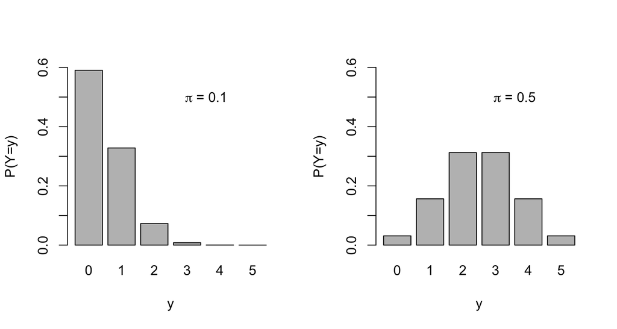

## Code that generates plot of previous slide

```r
par(mfrow=c(1,2), bg = NA)
y <- factor(0:5)
x <- 0:5
barplot(dbinom(x,5,.1),ylim=c(0,.6),names.arg=y,ylab="P(Y=y)",xlab="y")
text(5,.5,expression(paste(pi," = 0.1")))
barplot(dbinom(x,5,.5),ylim=c(0,.6),names.arg=y,ylab="P(Y=y)",xlab="y")
text(5,.5,expression(paste(pi," = 0.5")))
```

## Poisson distribution

The probability of \(y\) events within a time period (e.g. number of earthquakes in a year) \[ P(y|\lambda)=\frac{e^{-\lambda}\lambda^y}{y!}, \text{where } lambda=\text{rate parameter} \]

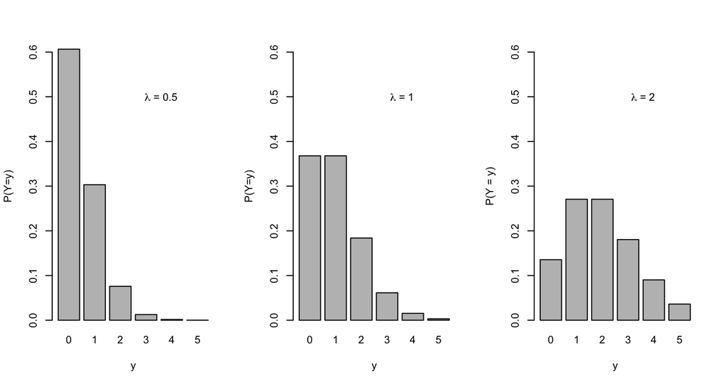

## Code that generates plot of previous slide

```r
par(mfrow = c(1, 3), bg = NA)
y <- factor(0:5)
x <- 0:5
barplot(dpois(x, .5),
        ylim = c(0, .6),
        names.arg = y,
        ylab = "P(Y=y)",
        xlab = "y")
text(5, .5, expression(paste(lambda, " = 0.5")))
barplot(dpois(x, 1),
        ylim = c(0, .6),
        names.arg = y,
        ylab = "P(Y=y)",
        xlab = "y")
text(5, .5, expression(paste(lambda, " = 1")))
barplot(dpois(x, 2),
        ylim = c(0, .6),
        names.arg = y,
        ylab = "P(Y = y)",
        xlab="y")
text(5,.5,expression(paste(lambda," = 2")))
```

## Continuous distributions

## Normal distribution: pdf en cdf

The probability density function (pdf):

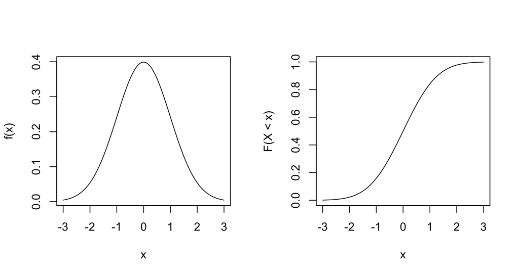

```r
par(mfrow=c(1,2), bg=NA)
curve(dnorm(x,0,1),xlim=c(-3,3),ylab="f(x)",main='')
curve(pnorm(x,0,1),xlim=c(-3,3),ylab="F(X < x)",main='')
```

## Exponential distribution

- Waiting times (e.g. time until occurrence eartquake) \[ f(t|\lambda)=\lambda{e}^{-\lambda{t}} \]

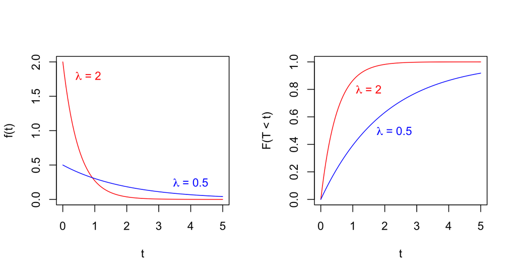

## Some more modeling

## Performing a t-test

```r
cats %$% t.test(Hwt ~ Sex)
```

```
##
##  Welch Two Sample t-test
##
## data:  Hwt by Sex
## t = -6.5179, df = 140.61, p-value = 1.186e-09
## alternative hypothesis: true difference in means is not equal to 0
## 95 percent confidence interval:
##  -2.763753 -1.477352
## sample estimates:
## mean in group F mean in group M
##        9.202128       11.322680
```

## Performing a chi-square test

```r
bacteria %>% head(n=8)
```

```
##   y ap hilo week  ID     trt
## 1 y  p   hi    0 X01 placebo
## 2 y  p   hi    2 X01 placebo
## 3 y  p   hi    4 X01 placebo
## 4 y  p   hi   11 X01 placebo
## 5 y  a   hi    0 X02   drug+
## 6 y  a   hi    2 X02   drug+
## 7 n  a   hi    6 X02   drug+
## 8 y  a   hi   11 X02   drug+
```

Column `y`:

- `n`: Disease absent.
- `y`: Disease present.

Column `ap`:

- `a`: Active medicine.
- `p`: Placebo.

## Performing a chi-square test

```r
bacteria %$% table(ap, y)
```

```
##    y
## ap   n  y
##   a 31 93
##   p 12 84
```

```r
x2.table <- table(bacteria$ap, bacteria$y)
x2.table <- cbind(x2.table, rowSums(x2.table))
rbind(x2.table, colSums(x2.table))
```

```
##    n   y
## a 31  93 124
## p 12  84  96
##   43 177 220
```

## chi-square tests

\[\chi^2 = \sum \frac{(O - E)^2}{E}\]

- Observed:

```
##    n   y
## a 31  93 124
## p 12  84  96
##   43 177 220
```

- Expected:

```
##    y
## ap         n        y
##   a 24.23636 99.76364
##   p 18.76364 77.23636
```

## Performing a chi-square test

```r
prop.table(table(bacteria$ap, bacteria$y), margin = 1)
```

```
##
##         n     y
##   a 0.250 0.750
##   p 0.125 0.875
```

- In the treatment condition, 1/4 is free of disease.
- In the placebo condition 1/8 is free of the disease.

Should we assume this means the medicine works?

## Performing a chi-square test

```r
bacteria %$% chisq.test(ap, y)
```

```
##
##  Pearson's Chi-squared test with Yates' continuity correction
##
## data:  ap and y
## X-squared = 4.6109, df = 1, p-value = 0.03177
```

or the other way around

```r
bacteria %$% chisq.test(y, ap)
```

```
##
##  Pearson's Chi-squared test with Yates' continuity correction
##
## data:  y and ap
## X-squared = 4.6109, df = 1, p-value = 0.03177
```

## Or, equivalently:

```r
bacteria %$% table(ap, y) %>% chisq.test
```

```
##
##  Pearson's Chi-squared test with Yates' continuity correction
##
## data:  .
## X-squared = 4.6109, df = 1, p-value = 0.03177
```

## Visualizing this

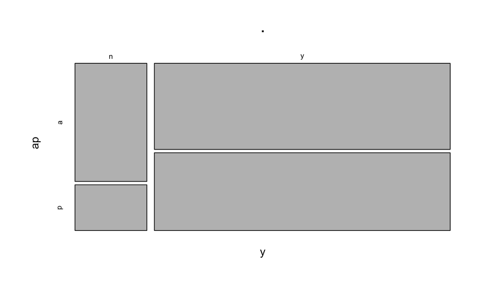

```r
bacteria %$% table(y, ap) %>% plot
```

## Visualizing this

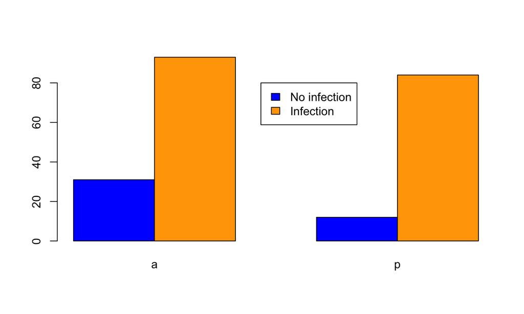

```r
barplot(table(bacteria$y, bacteria$ap),
        beside = TRUE,
        legend = c("No infection", "Infection"),
        col = c("blue", "orange"),
        args.legend = list(x=4.5, y=80))
```

## Fisher’s exact test

With small expected cell frequencies (roughly if any are below 5), we should use Fishers exact test.

```r
short <- bacteria %>%
  subset(week <= 2) %$%
  table(y, ap)
short
```

```
##    ap
## y    a  p
##   n  6  3
##   y 47 38
```

## Fisher’s exact test

```r
short %>% chisq.test
```

```
##
##  Pearson's Chi-squared test with Yates' continuity correction
##
## data:  .
## X-squared = 0.090475, df = 1, p-value = 0.7636
```

## Fisher’s exact test

```r
#fisher.test(table(short$y, short$ap))
short %>%
  fisher.test
```

```
##
##  Fisher's Exact Test for Count Data
##
## data:  .
## p-value = 0.7268
## alternative hypothesis: true odds ratio is not equal to 1
## 95 percent confidence interval:
##   0.3182193 10.5996850
## sample estimates:
## odds ratio
##   1.609049
```

What do we conclude?

## Visualizing this

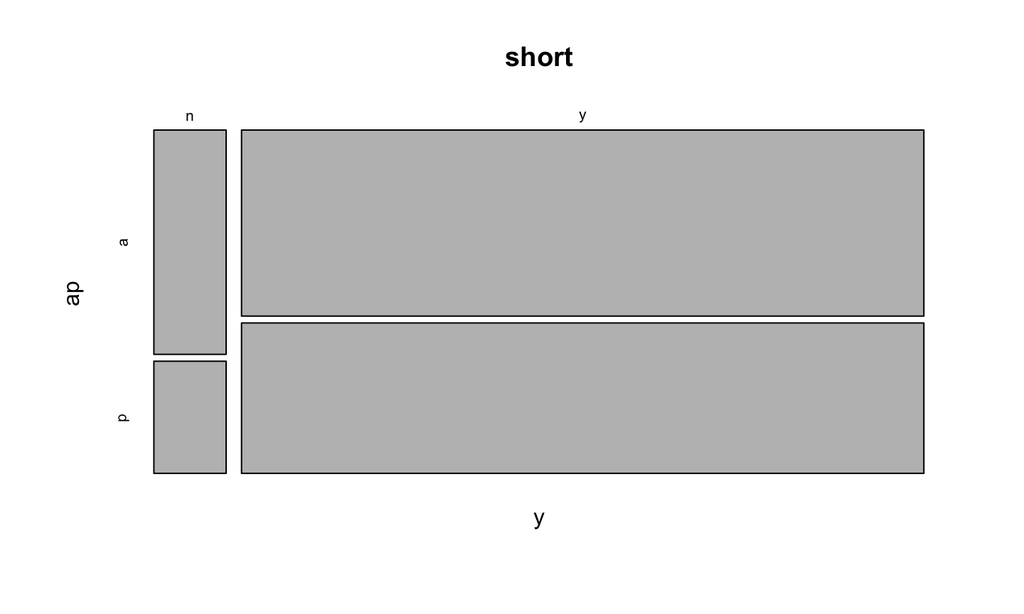

```r
plot(short)
```

## Visualizing this

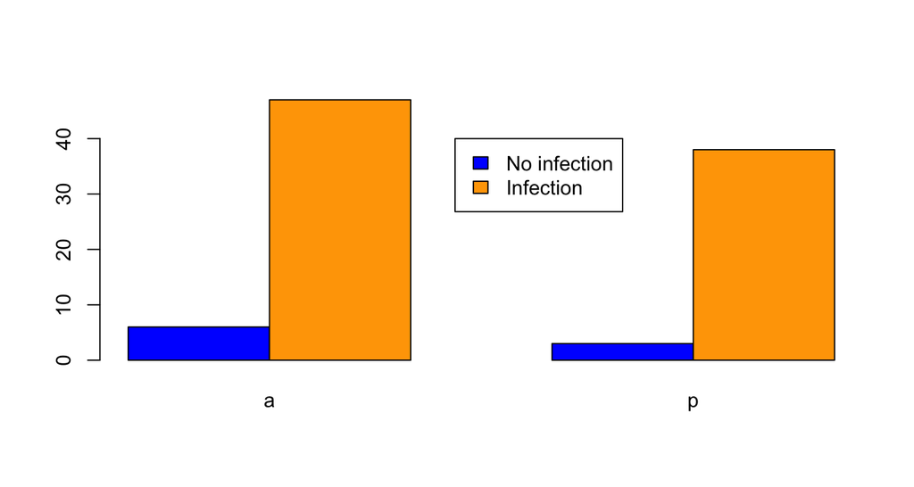

```r
barplot(short,
        beside = TRUE,
        legend = c("No infection", "Infection"),
        col = c("blue", "orange"),
        args.legend = list(x=4.5, y=40))
```